# Single_effect

Jungang Zou

4/28/2021

```r
# import packages and define some useful mathematical functions
knitr::opts_chunk$set(echo = TRUE)
library(parallel)
library(doParallel)
library(foreach)
library("MCMCpack")
sigmoid = function(x) return(1 / (1 + exp(-x)))

softmax = function(x){
  e_x = exp(x - max(x))
  return(e_x / sum(e_x))
}
```

## Genetic Association Selection based on Bayesian Methods

Nowadays, statistical genetics is becoming more and more popular. It uses statistical tools to find the statistical association between disease(or phenotype) with a set of candidate genes, which provides a pre-selection tool to Biologists. However, in genetic data, usually a large amount of genes(genotype data) are provided for each sample, but only few samples(each stands for an individual) are able to be exploited. This special biological context can lead to a lot of problems in statistical models, such as intensive computation, high dimension curse, non-invertible normal matrix in ordinary least square. On the other hand, Bayesian statistical method gives another framework to cope with genetic association problems, which mixes up the information based on personal belief and data. These kind of models are applied in statistical genetic problems more and more frequently.

To solve the problems caused by genetic data, a lot of different methods are proposed. The main ideas of these models are based on the fact that we only need to identify the most significant genes instead of the whole genetic dataset. In fact, a series of statistical methods built by frequentists can be exploited for the same application purpose, such as shrinkage method(Lasso for example), step-wise regression. These methods can identify the covariates of the most statistical significance. Also, in Bayesian framework, variable selection technique or model averaging technique can be used. Bayesian variable selection methods specify special prior distributions for parameters in regression, where the inference based on posterior distributions will show whether this covariate will be included in models. Among a broad range of priors, a very useful prior is [Spike-Slab prior](https://en.wikipedia.org/wiki/Spike-and-slab_regression). On the other hand, Bayesian Model Averaging considers probabilities of covariates subsets separately, instead of the whole dataset. In this method, datasets are separated into different subsets by columns, then regression models will be fitted on each subset of variables. Finally, posterior probability of each model will be calculated with the evidence of data. Generally speaking, there are totally $2^p$ models, $p$ denotes the number of genes. To reduce the intensive computation, “single effect” model is often specified, which separates the whole data into only $p$ different subsets and each subset contains only one variable(gene). For Bayesian Model Averaging, we consider the effect of only one gene separately, while the co-effect of all genes will be applied in Bayesian Variable Selection.

In this notebook, we code 2 algorithms to identify significant genes associated with phenotypes in R code, based on Bayesian Variable Selection technique and Bayesian Model Averaging technique respectively.

### Single Effect Logistic Regression based on Bayesian Model Averaging

The process of Single Effect Bayesian Model Averaging(BMA) can be followed by 5 steps: 1. Specify a prior inclusion probability for each single effect model $\pi(M_j),j=1,2...p$ with $\sum_1^p\pi(M_j) = 1$ constraint. 2. Specify prior of parameters in each model $\pi(\beta_0^j, \beta_1^j | M_j)$, then sample $\beta_0^j$ and $\beta_1^j$ from prior distribution. 3. Calculate likelihood under model $p(y |x^j, M_j ) = \int \int p(y|x^j, \beta_0^j, \beta_1^j, M_j) \pi(\beta_0^j, \beta_1^j | M_j) d\beta_0^jd\beta_1^j$ by Monte Carlo integrals. 4. Calculate posterior inclusion probability for each model by Bayes Rule $\pi(M_j | y, x^j) = \frac{\pi(M_j) *p(y |x^j, M_j ) }{\sum_1^p\pi(M_j) *p(y |x^j, M_j )}$. 5. Use MCMC or Variation Inference methods to infer posterior distributions for each pair ($\beta_0^j$, $\beta_1^j$), if needed.

#### Simple BMA without Inference

In most of the scenario of genetic association study, the effect of parameters for significant genes is not rather important. Instead, posterior inclusion probability(PIP) is what we concern about. Due to this convenient situation, the algorithm without inference is typically rapid, with no loop in the procedure.

In our algorithm, we specify a uniform distribution on user-defined interval $[lower, higher]$ for $\beta_0^j$, and user-defined normal distribution $Normal(\mu_0, \sigma_0^2)$ for $\beta_1^j$. The code of simple non-inference BMA method is as follow:

```r
# calculate log-likelihood for a pair of parameters.
log_logistic_likelihood = function(x, y, beta_0, beta_1, tol = 1e-100){
  lm = beta_0 + beta_1 * x
  return(sum(y * log(sigmoid(lm) + tol) + (1 - y) * log(1 - sigmoid(lm) + tol)))
}

# the main algorithm of Bayesian Model Averaging
# Input:
# X: a matrix of genotype data. The process of centralization or normalization should be calculated before this algorithm if needed.
# Y: a vector of phenotype data, only binary data(0 or 1) is allowed.
# prior_ip: prior inclusion probability for each model. The size of vector should be consistent with variables of X. If prior_ip is not normalized(sum to 1), a process of normalization will be done in algorithm.
# mu0: a scalar to specify the prior normal mean of beta_1
# sigma0: a scalar to specify the prior normal standard deviation of beta_1
# lower: a scalar to specify the prior lower bound of uniform distribution for beta_0
# higher: a scalar to specify the prior upper bound of uniform distribution for beta_0
# sample_size: a scalar to specify the number of samples for parameters to perform Monte Carlo Integral for p(data | M_j)

# output:
# A vector of posterior inclusion probability for each variable.

BMA_simple = function(X, Y, prior_ip, mu0, sigma0, lower, higher, sample_size = 10000){
  # preparation
  n = nrow(X)
  p = ncol(X)
  if(length(prior_ip) != p){
    stop("number of dimensions of prior inclusion probability and X are not consistent")
  }
  if(sum(prior_ip) != 1)
    prior_ip = prior_ip / sum(prior_ip)

  # sample parameters
  beta_0 = sapply(1:p, function(x){runif(sample_size, lower, higher)})
  beta_1 = sapply(1:p, function(x){rnorm(sample_size, mu0, sigma0)})

  # calculate log-likelihood condition on only model
  logp_likelihood = sapply(1:p, function(j){
    if (p == 1){
      beta_0_j = beta_0
      beta_1_j = beta_1
      x_j = X
    }else{
      beta_0_j = beta_0[, j]
      beta_1_j = beta_1[, j]
      x_j = X[, j]
    }
    log_likelihood_j = log(mean(exp(sapply(1:sample_size, function(i){
      log_logistic_likelihood(x_j, Y, beta_0_j[i], beta_1_j[i])
    }))))
    log_likelihood_j
  })

  # calculate PIP
  logp_prior_ip = log(prior_ip)
  posterior_ip = softmax(logp_prior_ip + logp_likelihood)
  return(posterior_ip)
}



# simulate
n = 100
mu0 = 0
sigma0 = 1
lower = -10
higher = 10
X = cbind(rnorm(n), rnorm(n, 1), rnorm(n, 1, 5))
b = c(2,5,-2)
Y = rbinom(n, 1, sigmoid(X %*% b + 2))

BMA_simple(X, Y, rep(1/ncol(X), ncol(X)), mu0, sigma0, lower, higher)
```

```
## [1] 4.760642e-14 2.560748e-11 1.000000e+00
```

#### BMA with Inference based on NUTS

Although in several genetic application, what we care about is only PIP. However, in another scenarios, we also concern about the statistical effect on each gene. Therefore the inference on the simple Bayesian logistic regression model should be done. In this sense, MCMC sampling model is applied to solve this difficult problem since Bayesian logistic regression consists of some complex expression and can not find the close form for posterior distributions of parameters. Considering about these continuous variables, Hamiltonian Monte Carlo Sampling(HMC) is what we need.

As we know, HMC is well-known monte carlo method for high-dimensional data. The basic idea is borrowed from Hamilton System, which is a classical dynamic system in physics. A brief introduction of HMC can be found [here](https://en.wikipedia.org/wiki/Hamiltonian_Monte_Carlo). However, HMC has several disadvantages. The most inconvenient one is that we need to tune 3 hyperparameters by hand: Mass Matrix(approximate to posterior variance), step size and step number. In empirical study, if these parameters are not well tuned, the MCMC chains are very hard to mix up and converge. In order to solve this problem, an advanced HMC algorithm call No-U-Turn Sampler(NUTS) are proposed in the [paper](https://arxiv.org/abs/1111.4246). Based on some complex mechanisms, these 3 parameters are tuned automatically.

In this part, we coding a NUTS algorithm to for Bayesian logistic regression model. Also, a unified convergence diagnostics function is provided followed by Gelman-Rubin`s statistics. And in next part, the NUTS sampling algorithm and simple BMA model will make up the whole inference model.

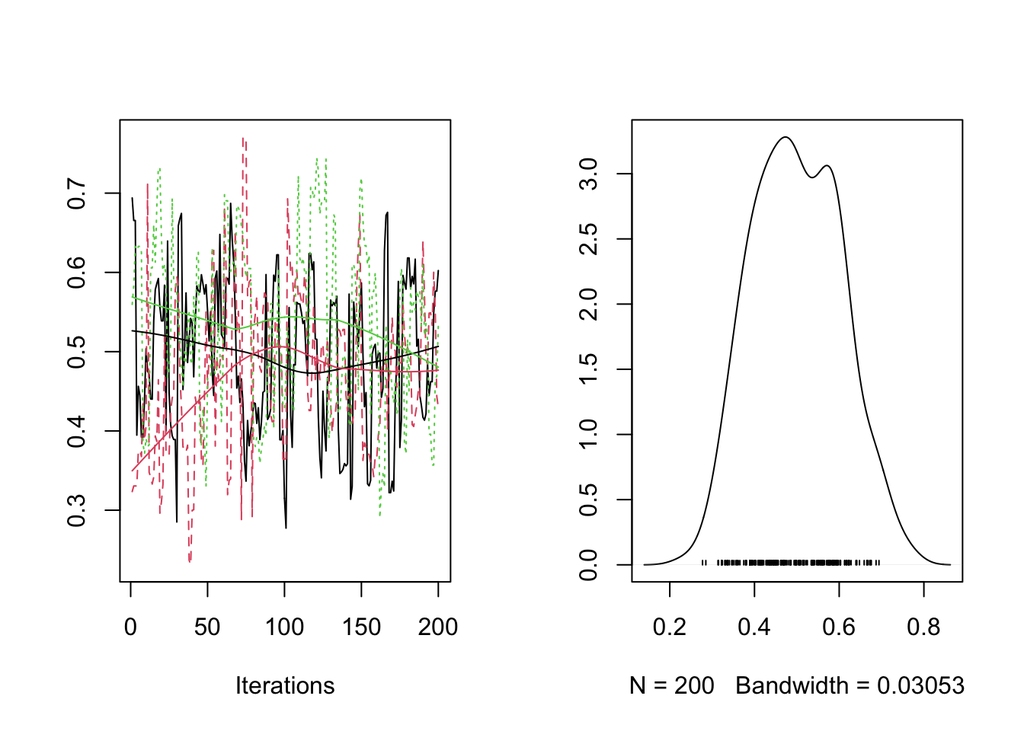

```
## Potential scale reduction factors:
##
##      Point est. Upper C.I.
## [1,]       1.08       1.23
```

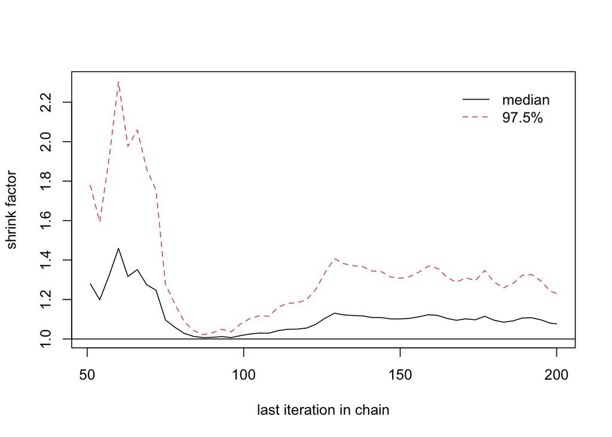

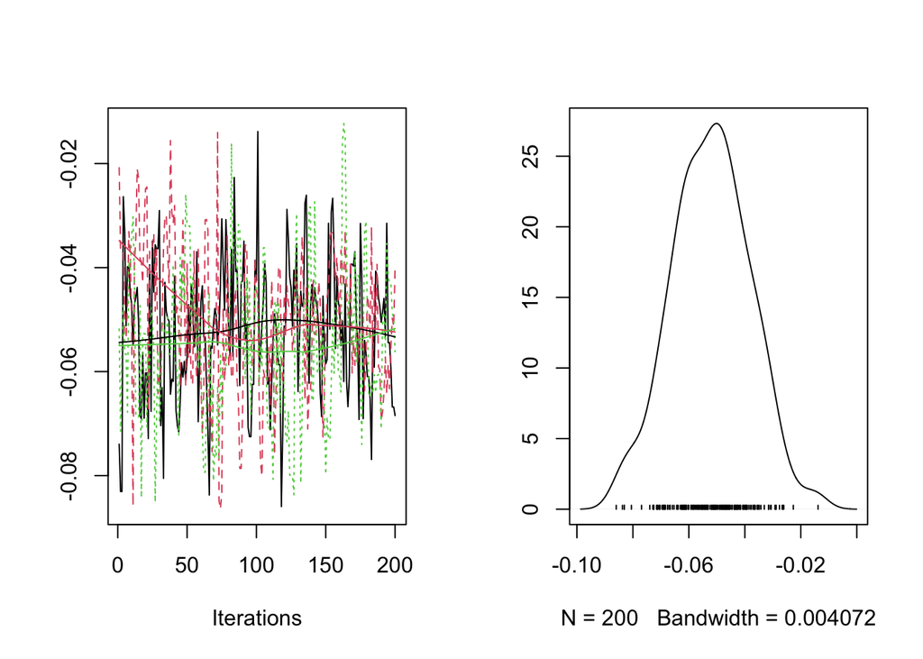

```
## Potential scale reduction factors:
##
##      Point est. Upper C.I.
## [1,]       1.04       1.09
```

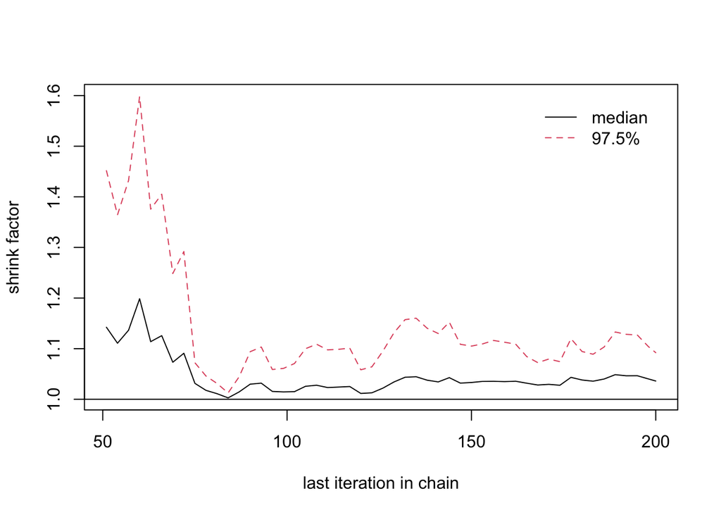

```r
# calculate the log posterior probability for fully model.
log_posterior = function(x, y, beta_0, beta_1, mu0, sigma0, tol = 1e-100){
  lm = beta_0 + beta_1 * x
  sum(y * log(sigmoid(lm) + tol) + (1 - y) * log(1 - sigmoid(lm) + tol)) - (beta_1 - mu0)^2/(2 * sigma0^2)
}

# calculate gradient for each parameters.
dlogp_dbeta0 = function(x, y, beta_0, beta_1){
  lm = beta_0 + beta_1 * x
  sum(y * (1 - sigmoid(lm)) + (y - 1) * sigmoid(lm))
}

dlogp_dbeta1 = function(x, y, beta_0, beta_1, mu0, sigma0){
  lm = beta_0 + beta_1 * x
  sum(y * x * (1 - sigmoid(lm)) + x * (y - 1) * sigmoid(lm)) - (beta_1 - mu0) / (sigma0^2)
}

# check if beta_0 is in accept region
beta_0_in_region = function(lower, higher, beta_0){
  if (beta_0 <= higher || beta_0 >= lower)
    return(TRUE)
  else
    return(FALSE)
}

# build sampling binary tree followed the instruction in NUTS paper
BuildTree = function(x, y, mu0, sigma0, lower, higher, beta, phi, u, v, j, e, delta_max = 1000){
  if (j == 0){
    e = e * v
    pd = c(dlogp_dbeta0(x, y, beta[1], beta[2]), dlogp_dbeta1(x, y, beta[1], beta[2], mu0, sigma0))
    phi = phi + 0.5 * e * pd

    beta = beta + e * phi

    pd = c(dlogp_dbeta0(x, y, beta[1], beta[2]), dlogp_dbeta1(x, y, beta[1], beta[2], mu0, sigma0))
    phi = phi + 0.5 * e * pd


    if(!beta_0_in_region(lower, higher, beta[1]))
            phi[1] = phi[1] * -1

    if(beta_0_in_region(lower, higher, beta[1]) && log(u) <= log_posterior(x, y, beta[1], beta[2], mu0, sigma0, tol = 1e-100) - 0.5 * phi %*% phi ){
      C2 = c(beta, phi)
    }
    else{
      C2 = c()
    }
    s2 = (log(u) < log_posterior(x, y, beta[1], beta[2], mu0, sigma0, tol = 1e-100) - 0.5 * phi %*% phi + delta_max)
    return(list(beta_negative = beta, phi_negative = phi, beta_positive = beta, phi_positive = phi, C2 = C2, s2 = s2))
  }
  else{
      result = BuildTree(x, y, mu0, sigma0, lower, higher, beta, phi, u, v, j - 1, e)
      beta_negative = result$beta_negative
      phi_negative = result$phi_negative
      beta_positive = result$beta_positive
      phi_positive = result$phi_positive
      C2 = result$C2
      s2 = result$s2
      if(v == -1){
        result = BuildTree(x, y, mu0, sigma0, lower, higher, beta_negative, phi_negative, u, v, j - 1, e)
        beta_negative = result$beta_negative
        phi_negative = result$phi_negative
        C3 = result$C2
        s3 = result$s2
      }
      else{
        result = BuildTree(x, y, mu0, sigma0, lower, higher, beta_positive, phi_positive, u, v, j - 1, e)
        beta_positive = result$beta_positive
        phi_positive = result$phi_positive
        C3 = result$C2
        s3 = result$s2
      }
      s2 = s2 * s3 * (((beta_positive - beta_negative) %*% phi_negative) >= 0) * (((beta_positive - beta_negative) %*% phi_positive) >= 0)
      C2 = rbind(C2, C3)
      return(list(beta_negative = beta_negative, phi_negative = phi_negative, beta_positive = beta_positive, phi_positive = phi_positive, C2 = C2, s2 = s2))
  }
}


# NUTS algorithm for sampling one sample.
NUTS = function(x, y, beta, mu0, sigma0, lower, higher, e = 0.1){
  phi = rnorm(2, mean = c(0, 0), sd = c(1, 1))
  u = runif(1, min = 0, max = exp(log_posterior(x, y, beta[1], beta[2], mu0, sigma0, tol = 1e-100) - 0.5 * phi %*% phi))
  beta_negative = beta
  beta_positive = beta
  phi_negative = phi
  phi_positive = phi
  j = 0
  C = c(beta, phi)
  s = 1
  while (s == 1) {
    v_j = sample(c(1, -1), 1)
    if (v_j == -1) {
      result = BuildTree(x, y, mu0, sigma0, lower, higher, beta_negative, phi_negative, u, v_j, j, e)
      beta_negative = result$beta_negative
      phi_negative = result$phi_negative
      C2 = result$C2
      s2 = result$s2
    }else{
      result = BuildTree(x, y, mu0, sigma0, lower, higher, beta_positive, phi_positive, u, v_j, j, e)
      beta_positive = result$beta_positive
      phi_positive = result$phi_positive
      C2 = result$C2
      s2 = result$s2
    }
    #print(s2)
    if (s2 == 1){
      C = rbind(C, C2)
    }
    s = s2 * (((beta_positive - beta_negative) %*% phi_negative) >= 0) * (((beta_positive - beta_negative) %*% phi_positive) >= 0)
    j = j + 1
  }
  return(C[sample.int(nrow(C), size = 1), ])
}


# The main sampling algorithm for Bayesian logistic regression
# Input:
# burn_n: an integer to specify the number of burn-in turns.
# sample_n: an integer to specify the number of samplers.
# sample_gap: an integer to specify the number of sampling gap, which mean we only get 1 samples from total gap samples. Basically, there are (sample_n * sample_gap) turns to sample after burn-in phrase.
# x: a vector of genotype data, only for one gene.
# y: a vector of phenotype data, only binary data(0 or 1) is allowed.
# beta_0: a scalar for initial value of $\beta_0$
# beta_1: a scalar for initial value of $\beta_1$
# mu0: a scalar to specify the prior normal mean of beta_1
# sigma0: a scalar to specify the prior normal standard deviation of beta_1
# lower: a scalar to specify the prior lower bound of uniform distribution for beta_0
# higher: a scalar to specify the prior upper bound of uniform distribution for beta_0
# e: the step size in NUTS algorithm

# output:
# A matrix, each row is a sample for (beta_0, beta_1)
bayes_logit = function(burn_n, sample_n, sample_gap = 1, x, y, beta_0, beta_1, mu0, sigma0, lower, higher, e = 0.01){
  beta_sample = c()
  beta = c(beta_0, beta_1)

  # burn-in phrase
  for (i in 1:burn_n) {
    result = NUTS(x, y, beta, mu0, sigma0, lower, higher, e)
    beta = result[c(1, 2)]
  }

  # sampling phrase
  for (i in 1:(sample_n * sample_gap)) {
    result = NUTS(x, y, beta, mu0, sigma0, lower, higher, e)
    beta = result[c(1, 2)]
    # sampling gap
    if (i %% sample_gap == 0){
      beta_sample = rbind(beta_sample, beta)
    }
  }
  return(beta_sample)
}


# The convergence diagnostics algorithm for Bayesian Logistic regression
# Input:
# beta_0: a list of samplers of beta_0 in multiple chains.
# beta_1: a list of samplers of beta_1 in multiple chains.
# plot_: a logical scalar, to decide whether the diagnostic plot is needed to output.

# output:
# A list of 2 element, one is the gelman-rubin`s statistics for beta_0, the other is for beta_1.
HMC_convergence = function(beta_0, beta_1, plot_ = T){
  beta_0_mcmc = lapply(beta_0, function(x) mcmc(x))
  beta_1_mcmc = lapply(beta_1, function(x) mcmc(x))

  # diagnose for beta_0
  combinedchains_beta_0 = mcmc.list(beta_0_mcmc)
  if (plot_) {
    plot(combinedchains_beta_0)
    print(gelman.diag(combinedchains_beta_0))
    gelman.plot(combinedchains_beta_0)
  }


  # diagnose for beta_1
  combinedchains_beta_1 = mcmc.list(beta_1_mcmc)
  if (plot_) {
    plot(combinedchains_beta_1)
    print(gelman.diag(combinedchains_beta_1))
    gelman.plot(combinedchains_beta_1)
  }

  return(list(beta0_gelman = gelman.diag(combinedchains_beta_0)$psrf[1], beta1_gelman = gelman.diag(combinedchains_beta_1)$psrf[1]))
}

# simulate
n = 1000
X = cbind(rnorm(n, 10), rnorm(n, 1), rnorm(n, 1, 5))
X = X - colMeans(X)
b = c(2,5,-2)
Y = rbinom(n, 1, sigmoid(X %*% b + 2))
x = X[, 1]
y = Y


# run 3 chains at different starting points
beta0 = runif(1, lower, higher)
beta1 = rnorm(1, mu0, sigma0)
#beta = c(beta0, beta1)
samples1 = bayes_logit(200, 200,2, x, Y, beta0, beta1, 0, 1, -10, 10, e = 0.01)

beta0 = runif(1, lower, higher)
beta1 = rnorm(1, mu0, sigma0)
samples2 = bayes_logit(200, 200,2, x, Y, beta0, beta1, 0, 1, -10, 10, e = 0.01)

beta0 = runif(1, lower, higher)
beta1 = rnorm(1, mu0, sigma0)
samples3 = bayes_logit(200, 200,2, x, Y, beta0, beta1, 0, 1, -10, 10, e = 0.01)


# gather samples according to the input of HMC_convergence
beta_0 = list(samples1[,1], samples2[,1], samples3[,1])
beta_1 = list(samples1[,2], samples2[,2], samples3[,2])


# get the convergence result
convergence = HMC_convergence(beta_0, beta_1)
```

```r
convergence
```

```
## $beta0_gelman
## [1] 1.076463
##
## $beta1_gelman
## [1] 1.036074
```

After the test for MCMC algorithm, we construct the BMA_inference algorithm based on NUTS and simple BMA. In addition, the function of multiple chains to check convergence are also provided inside the whole algorithm. If multiple chains are needed, then parallel computing for sampling will be used.

```r
# calculate log-likelihood for a pair of parameters.
log_logistic_likelihood = function(x, y, beta_0, beta_1, tol = 1e-100){
  lm = beta_0 + beta_1 * x
  return(sum(y * log(sigmoid(lm) + tol) + (1 - y) * log(1 - sigmoid(lm) + tol)))
}



# the main algorithm of Bayesian Model Averaging with Inference
# Input:
# X: a matrix of genotype data. The process of centralization or normalization should be calculated before this algorithm if needed.
# Y: a vector of phenotype data, only binary data(0 or 1) is allowed.
# prior_ip: prior inclusion probability for each model. The size of vector should be consistent with variables of X. If prior_ip is not normalized(sum to 1), a process of normalization will be done in algorithm.
# mu0: a scalar to specify the prior normal mean of beta_1
# sigma0: a scalar to specify the prior normal standard deviation of beta_1
# lower: a scalar to specify the prior lower bound of uniform distribution for beta_0
# higher: a scalar to specify the prior upper bound of uniform distribution for beta_0
# sample_size: a scalar to specify the number of samples for parameters to perform Monte Carlo Integral for p(data | M_j)
# n_chain : an integer to specify the number of chains needed in convergence diagnostics. And only the samples from the first chain will be returned.
# burn_n: an integer to specify the number of burn-in turns.
# sample_n: an integer to specify the number of samplers.
# sample_gap: an integer to specify the number of sampling gap, which mean we only get 1 samples from total gap samples. Basically, there are (sample_n * sample_gap) turns to sample after burn-in phrase.
# e: a scalar to specify the step size parameter in NUTS.

# output:
# A list. The first element is a vector of posterior inclusion probability for each variable. The second vector is Gelman-Rubin statistics and samples for each gene.
BMA_inference = function(X, Y, prior_ip, mu0, sigma0, lower, higher, sample_size = 10000, n_chain = 3, burn_n = 200, sample_n = 200, sample_gap = 1, e = 0.01){
  n = nrow(X)
  p = ncol(X)
  if(length(prior_ip) != p){
    stop("number of dimensions of prior inclusion probability and X are not consistent")
  }
  if(sum(prior_ip) != 1)
    prior_ip = prior_ip / sum(prior_ip)
  beta_0 = sapply(1:p, function(x){runif(sample_size, lower, higher)})
  beta_1 = sapply(1:p, function(x){rnorm(sample_size, mu0, sigma0)})



  # parallel sampling
  registerDoParallel(4)

  # run sampling algorithm for each gene
  chains = sapply(1:p, function(j){

    # sample multiple chain
    multiple_chains = foreach(i = 1:n_chain, .combine = cbind) %dopar% {
    beta0 = beta_0[i, j]
    beta1 = beta_1[i, j]
    bayes_logit(burn_n, sample_n, sample_gap, x, Y, beta0, beta1, mu0, sigma0, lower, higher, e)
    }

    result = list()
    if (n_chain == 1) {
      # if sample only one chain, then just return samples
      result[["beta_0_samples"]] = beta_0[[1]]
      result[["beta_1_samples"]] = beta_1[[1]]
      result[["beta_0_mean"]] = mean(beta_0[[1]])
      result[["beta_1_mean"]] = mean(beta_1[[1]])
      return(result)
    }
    else{
      # if sample for multiple chains, then Gelman-rubin`s statistics is calculated. The statistics and the samples from the first chain are returned.
      beta_0 = list()
      beta_1 = list()
      for (i in 1:n_chain) {
        beta_0[[i]] = multiple_chains[, i * 2 - 1]
        beta_1[[i]] = multiple_chains[, i * 2]
      }
      result = HMC_convergence(beta_0, beta_1, plot_ = FALSE)
      result[["beta_0_samples"]] = beta_0[[1]]
      result[["beta_1_samples"]] = beta_1[[1]]
      result[["beta_0_mean"]] = mean(beta_0[[1]])
      result[["beta_1_mean"]] = mean(beta_1[[1]])
      return(result)
    }
  })


  # calculate log-likelihood condition on only model
  logp_likelihood = sapply(1:p, function(j){
    if (p == 1){
      beta_0_j = beta_0
      beta_1_j = beta_1
      x_j = X
    }else{
      beta_0_j = beta_0[, j]
      beta_1_j = beta_1[, j]
      x_j = X[, j]
    }
    log_likelihood_j = log(mean(exp(sapply(1:sample_size, function(i){
      log_logistic_likelihood(x_j, Y, beta_0_j[i], beta_1_j[i])
    }))))
    log_likelihood_j
  })

  # calculate PIP
  logp_prior_ip = log(prior_ip)
  posterior_ip = softmax(logp_prior_ip + logp_likelihood)
  return(list(posterior_ip, chains))
}

# simulate
n = 1000
X = cbind(rnorm(n, 10), rnorm(n, 1), rnorm(n, 1, 5))
X = X - colMeans(X)
b = c(2,5,-2)
Y = rbinom(n, 1, sigmoid(X %*% b + 2))
result = BMA_inference(X, Y, rep(1/ncol(X), ncol(X)), 0, 1, -10, 10)
result
```

```
## [[1]]
## [1] 9.719427e-149  1.000000e+00  7.688851e-37
##
## [[2]]
##                [,1]        [,2]        [,3]
## beta0_gelman   1.498828    1.628616    1.164638
## beta1_gelman   1.282742    1.493011    1.080221
## beta_0_samples Numeric,200 Numeric,200 Numeric,200
## beta_1_samples Numeric,200 Numeric,200 Numeric,200
## beta_0_mean    0.4180867   0.3790181   0.392569
## beta_1_mean    -0.04161409 -0.03484021 -0.03778587
```

# The rest of notebook has not been completed yet and will be done a few days later.

### Bayesian Variable Selection based Logistic Regression

This a Hamilton Monte Carlo Implementation for “Single effect” Bayesian Logistic Regression. In some genetic background, we need to find the association between a specific phenotype(disease or not) and a set of genes. In traditional setting, logistic regression can be used to cope with such problem. However, as the number of tested genes grows very rapidly, traditional logistic regression has several backdrops, that identifies very low association for each gene. In order to solve this problem, Bayesian Variable Selection are applied to select the most “significant” genes. In some extreme situations, only one gene are expected to be select.

In the fully-Bayesian model, vanilla logistic regression can be treated as $y \sim Bernoulli(sigmoid(b_0 + Xb))$, where $sigmoid(x) = \frac{1}{1 + exp(-x)}$. Introducing Variable Selection technique, we add a new discrete variable $g$, such that $g_i$ indicates the prior inclusion probability that $b_i$ will be included in regression model. Therefore, the whole likelihood will be $y \sim Bernoulli(sigmoid(b_0 + X(b \odot g)))$. Based on this model, we set the prior of $b_0$ as a flat prior which means $b_0 \varpropto 1$, and specify normal distribution for each $b_j$ as $b_j \sim N(\mu_0, \sigma_0)$. Since $g$ follows a discrete variable, we specify a vector prior $g_0$ for $g$ where $\sum_ig_{0i} = 1$ and a discrete uniform distribution will be used as default.

### Simple Bayesian Logistic Regression

#### Fully-Bayesian Model

To get the complete fully-Bayesian model, we need to carefully write down the likelihood function, prior and posterior distributions:

Likelihood: $f(Y|X,b_0, b) = \prod_i^n (sigmoid(b_0 + X_i(b \odot g)))^{y_i}(1 - sigmoid(b_0 + X_ib)))^{1 - y_i}$

Prior: $b_0 \varpropto 1$, $\pi(b_i) \varpropto exp(-\frac{(b_i - \mu_0)^2}{2\sigma_0^2})$..

Fully Posterior: $p(Y, b_0, b | X) \varpropto \prod_i^n (sigmoid(b_0 + X_ib ))^{y_i}(1 - sigmoid(b_0 + X_ib))^{1 - y_i} * \prod_j^p exp(-\frac{(b_j - \mu_0)^2}{2\sigma_0^2})$

### Fully-Bayesian Model

To get the complete fully-Bayesian model, we need to carefully write down the likelihood function, prior and posterior distributions:

Likelihood: $f(Y|X,b_0, b, g) = \prod_i^n (sigmoid(b_0 + X_i(b \odot g)))^{y_i}(1 - sigmoid(b_0 + X_i(b \odot g)))^{1 - y_i}$

Prior: $b_0 \varpropto 1$, $\pi(b_i) = \frac{1}{\sqrt{2\pi}\sigma_0}exp(-\frac{(b_i - \mu_0)^2}{2\sigma_0^2})$, $\pi(g_{0i}) = \frac{1}{p}$, where $p$ stands for the number of predictors.

Fully Posterior: $p(Y, b_0, b, g | X) \varpropto \prod_i^n (sigmoid(b_0 + X_i(b \odot g)))^{y_i}(1 - sigmoid(b_0 + X_i(b \odot g)))^{1 - y_i} * \prod_i^p \frac{1}{\sigma_0}exp(-\frac{(b_i - \mu_0)^2}{2\sigma_0^2})$